# Hypothesis Testing- Discovery

Notes and in-class exercises

You can download the .qmd file for this activity here and open in R-studio. The rendered version is posted in the [course website](https://mutasim221b.github.io/Mac-STAT-155-Sp-26/) (Activities tab). I often experiment with the class activities (and see it in live!) and make updates, but I always post the final version before class starts. To be sure you have the most up-to-date copy, please download it once you’ve settled in before class begins.

# Notes

- You can download a template file to work with here.
- **File organization:** Save this file in the “Activities” subfolder of your “STAT155” folder.

## Learning goals

By the end of this lesson, you should be able to:

- Understand how standard errors and confidence intervals enable us to make statistical inferences
- Articulate how we can formalize a research question as a testable, statistical hypothesis

## Readings and videos

This is a discovery activity, so no assigned readings/videos today.

# Exercises

Let’s return to the `fish` dataset. Recall that rivers contain small concentrations of mercury which can accumulate in fish. Scientists studied this phenomenon among 171 largemouth bass in the Wacamaw and Lumber rivers of North Carolina, recording the following:

| variable | meaning |
| --- | --- |
| River | Lumber or Wacamaw |
| Station | Station number where the fish was caught (0, 1, …, 15) |
| Length | Fish’s length (in centimeters) |
| Weight | Fish’s weight (in grams) |
| Concen | Fish’s mercury concentration (in parts per million; ppm) |

```r
# Load the data & packages
library(tidyverse)
fish <- read_csv("https://mac-stat.github.io/data/Mercury.csv")

head(fish)
## # A tibble: 6 × 5
##   River  Station Length Weight Concen
##   <chr>    <dbl>  <dbl>  <dbl>  <dbl>
## 1 Lumber       0   47     1616   1.6
## 2 Lumber       0   48.7   1862   1.5
## 3 Lumber       0   55.7   2855   1.7
## 4 Lumber       0   45.2   1199   0.73
## 5 Lumber       0   44.7   1320   0.56
## 6 Lumber       0   43.8   1225   0.51
```

## Exercise 1

**Research question:** Is there evidence that the mercury concentration in fish (`Concen`) differs according to the `River` they were sampled from?

### part a: fit the model

Fit a simple linear regression model that would address our research question

```r
mod_fish <- lm(Concen ~ River, data=fish)
summary(mod_fish)
##
## Call:
## lm(formula = Concen ~ River, data = fish)
##
## Residuals:
##     Min      1Q  Median      3Q     Max
## -1.1664 -0.5681 -0.1764  0.4219  2.4219
##
## Coefficients:
##              Estimate Std. Error t value Pr(>|t|)
## (Intercept)   1.07808    0.08866  12.160   <2e-16 ***
## RiverWacamaw  0.19835    0.11712   1.694   0.0922 .
## ---
## Signif. codes:  0 '***' 0.001 '**' 0.01 '*' 0.05 '.' 0.1 ' ' 1
##
## Residual standard error: 0.7575 on 169 degrees of freedom
## Multiple R-squared:  0.01669,    Adjusted R-squared:  0.01087
## F-statistic: 2.868 on 1 and 169 DF,  p-value: 0.09218
```

Interpret the intercept from this model.

> Our model estimates an average mercury concentration of 1.078ppm among fish in the Lumber River.

### part b: construct a CI

Using the 68-95-99.7 rule, construct an approximate 95% confidence interval for the intercept term, and provide an appropriate interpretation.

```r
# approximate 95% confidence interval

1.078 + 2*0.089
## [1] 1.256
1.078 - 2*0.089
## [1] 0.9
```

> Preferred interpretation: It is plausible that the true mean mercury concentration among fish in the Lumber River is between 0.90ppm and 1.25ppm.

> (technical addendum to this interpretation): …specifically, we expect that if we take many different samples and obtain a set of corresponding parameter estimates and confidence intervals, we expect that 95% of the resulting intervals will contain the true mean mercury concentration of the entire Lumber River fish population. We hope that our interval is one of the lucky 95% and not one of the unlucky 5% that don’t contain the true population parameter.

> Not as preferred interpretation, but still okay for this course: We are 95% confident that the mean mercury concentration among fish in the Lumber River is between 0.90ppm and 1.25ppm.

Compare your CI to an exact 95% confidence interval for the model coefficients:

```r
confint(mod_fish, level=0.95)
##                    2.5 %    97.5 %
## (Intercept)   0.90305825 1.2531061
## RiverWacamaw -0.03285077 0.4295435
```

### part c: what can we conclude from multiple samples?

Suppose we take 200 different samples of fish from the Lumber River. Based on these results, in how many of those samples would you expect to observe mean mercury concentration **greater than** 1.25ppm?

> We don’t/can’t actually know! This depends on the true population parameter and the accuracy of our sampling distribution.

> What we *can* say is that if our sampling distribution model is accurate, then we should expect that about 10 out of 200 samples (5% of them) will produce confidence intervals that *don’t* contain the population parameter. We should expect that half of these–so 5 samples–are overestimates and the other half are underestimates.

### part d: intuition for constructing & interpreting test statistics

Suppose previous environmental studies have found little evidence of mercury pollution in other rivers in the area, so perhaps our “default” assumption is that fish from the Lumber river *should* have an expected mercury concentration of 0ppm. How many standard errors is our sample estimate (1.078ppm) away from this expectation? What are three possible conclusions?

> If we assume that 0ppm is the “true” mercury concentration, then our estimate of Beta_0 = 1.078ppm with a standard error of 0.08866 means that our estimate is (1.07808-0)/0.08866 = 12.16 standard errors away from what we should expect.

> Possible conclusions:
> 1. Our working assumption that 0ppm should be the “true” mercury concentration in the Lumber river fish population was wrong! The confidence interval we constructed above suggests that a true value of 0ppm is extremely implausible.
> 2. Perhaps ~0ppm is actually the true average mercury concentration in the population, we just got extremely, outrageously unlucky with our sample.
> 3. Perhaps there was a measurement/data entry error, and the units are actually parts per billion, not million.

### part e: do individual observations contradict our conclusions?

Now suppose we sample a *single* fish from the Lumber River and find it has a mercury concentration of 2.5ppm. Are you surprised by this result? Why or why not? (Hint: create a code chunk that calculates the mean, standard deviation, and maximum of the `Concen` variable in each river in our original sample)

```r
fish %>%
  group_by(River) %>%
  summarise(mean=mean(Concen),
            sd=sd(Concen),
            max=max(Concen))
## # A tibble: 2 × 4
##   River    mean    sd   max
##   <chr>   <dbl> <dbl> <dbl>
## 1 Lumber   1.08 0.649   3.5
## 2 Wacamaw  1.28 0.829   3.6
```

> Class Notes

**Additional Reading (after class): FORMAL HYPOTHESIS TESTS**

Though CIs can help us evaluate hypotheses, **hypothesis tests** provide a more formal approach. The general idea:

1. Assume that the hypothesis is *not* true.
2. Determine what sample observations would be *expected* under this assumption.
3. Evaluate how compatible *our* observed sample data are with this assumption (are they consistent with what we’d expect?).

Or, in context:

1. Assume there were truly *no* association between mercury concentration and fish length, i.e. $\beta_1 = 0$ (the “null value”).
2. Determine how our fish sample might have “behaved” if there were truly no association.
3. Evaluate how compatible our fish sample observations are with the null value (are they consistent with what we’d expect if there were no association?).

## Exercise 2:

Let’s look at the model summary output again:

```r
summary(mod_fish)
##
## Call:
## lm(formula = Concen ~ River, data = fish)
##
## Residuals:
##     Min      1Q  Median      3Q     Max
## -1.1664 -0.5681 -0.1764  0.4219  2.4219
##
## Coefficients:
##              Estimate Std. Error t value Pr(>|t|)
## (Intercept)   1.07808    0.08866  12.160   <2e-16 ***
## RiverWacamaw  0.19835    0.11712   1.694   0.0922 .
## ---
## Signif. codes:  0 '***' 0.001 '**' 0.01 '*' 0.05 '.' 0.1 ' ' 1
##
## Residual standard error: 0.7575 on 169 degrees of freedom
## Multiple R-squared:  0.01669,    Adjusted R-squared:  0.01087
## F-statistic: 2.868 on 1 and 169 DF,  p-value: 0.09218
```

### part a: interpret model coefficient

Now, let’s interpret the `RiverWacamaw` coefficient. Based *only* on the coefficient (don’t think about the standard error yet), what can we say about the difference in mercury concentration among fish in the two rivers?

> **Response**

### part b: construct a CI

Using the 68-95-99.7 rule, construct an approximate 95% confidence interval for the `RiverWacamaw` coefficient, and provide an appropriate interpretation.

> **Response**

### part c: interpreting the CI

Do you believe it *plausible* that the mean mercury concentration of the fish population in the Wacamaw River is approximately the same as that of the fish population in the Lumber River? How would you confirm this? What assumptions are you making?

> **Response**

### part d: effect of sample size on our conclusions

Suppose we sample 10 times as many fish from the Wacamaw River, and get a similar coefficient estimate (0.2). Thinking back to the Central Limit Theorem, what should happen to the standard error of the `RiverWacamaw` coefficient? How small of a standard error would we need to more conclusively say that there is an actual difference in mean mercury concentrations of the Lumber River and Wacamaw River fish populations?

> **Response**

### part e: reconciling parameter estimates and uncertainty

Suppose the *true* population coefficient for the `RiverWacamaw`parameter is 0.02 (i.e. the average mercury concentration is 0.02ppm higher for the Wacamaw River fish population compared to that of the Lumber River). Is this meaningful?

> **Response**

### part f (CHALLENGE)

Using the model summary output, report the mean mercury concentration for our sample of fish from the *Wacamaw River*:

```r
summary(mod_fish)
##
## Call:
## lm(formula = Concen ~ River, data = fish)
##
## Residuals:
##     Min      1Q  Median      3Q     Max
## -1.1664 -0.5681 -0.1764  0.4219  2.4219
##
## Coefficients:
##              Estimate Std. Error t value Pr(>|t|)
## (Intercept)   1.07808    0.08866  12.160   <2e-16 ***
## RiverWacamaw  0.19835    0.11712   1.694   0.0922 .
## ---
## Signif. codes:  0 '***' 0.001 '**' 0.01 '*' 0.05 '.' 0.1 ' ' 1
##
## Residual standard error: 0.7575 on 169 degrees of freedom
## Multiple R-squared:  0.01669,    Adjusted R-squared:  0.01087
## F-statistic: 2.868 on 1 and 169 DF,  p-value: 0.09218
```

> **Response:**

Which of the following values do you think is the standard error of the sample mean for the Wacamaw River?

- 0.11712
- 0.08866
- 0.11712 + 0.08866 = 0.20578
- 0.11712 - 0.08866 = 0.02846
- something else

To answer this question, look at the code chunk below, which fits the same model, but uses the Wacamaw River as our reference category instead of the Lumber River:

```r
mod_fish2 <- lm(Concen ~ River, data=fish %>% mutate(River=ifelse(River == "Wacamaw", paste0("_", River), River)))
summary(mod_fish2)
##
## Call:
## lm(formula = Concen ~ River, data = fish %>% mutate(River = ifelse(River ==
##     "Wacamaw", paste0("_", River), River)))
##
## Residuals:
##     Min      1Q  Median      3Q     Max
## -1.1664 -0.5681 -0.1764  0.4219  2.4219
##
## Coefficients:
##             Estimate Std. Error t value Pr(>|t|)
## (Intercept)  1.27643    0.07652  16.681   <2e-16 ***
## RiverLumber -0.19835    0.11712  -1.694   0.0922 .
## ---
## Signif. codes:  0 '***' 0.001 '**' 0.01 '*' 0.05 '.' 0.1 ' ' 1
##
## Residual standard error: 0.7575 on 169 degrees of freedom
## Multiple R-squared:  0.01669,    Adjusted R-squared:  0.01087
## F-statistic: 2.868 on 1 and 169 DF,  p-value: 0.09218
```

Compare this to the output for `mod_fish`. What do you notice about the standard errors of the intercepts (i.e., the standard errors of the means for each river) compared to the standard errors of the `RiverWacamaw` and `RiverLumber` coefficients (i.e., the standard errors of the **differences** between the means)?

> **Response:**

# Additional Exercise

**NOTE**

- The goal of these additional exercises is to explore *concepts* in hypothesis testing. There’s some new code that helps with this exploration, but the *code is not the point*!! Throughout, focus on the *goal* of the code and what its *output* tells us, NOT the *details* of the code.
- Our results will start to use more **scientific notation**. Examples:
  - `3e-02` = 0.03 (move the decimal 2 places to the *left*)
  - `3e02` = 300 (move the decimal 2 places to the *right*)
  - `4.12e-07` = 0.000000412 (move the decimal 7 places to the *left*)
  - `4.12e03` = 4120 (move the decimal 3 places to the *right*)
  - `< 2e-16` = the result is *less than* 0.0000000000000002 (it’s really really small!)

## Exercise 1: Simulating data under the null value

To begin testing our *hypothesis* that there *is* an association between mercury concentration and fish length ($\beta_1 \ne 0$), let’s explore how our sample data might behave IF in fact there were *no* association ($\beta_1 = 0$). We’ll first do this using *simulation*, and then through *theory*.

1. Read carefully:
- Suppose that when each individual fish in our sample was collected, the scientists wrote its `Concen` and `Length` on a piece of paper.
- They then ripped the paper in half, with the observed `Concen` on one half and the observed `Length` on the other.
- They then accidentally dropped the pieces of paper! In the resulting mess, they couldn’t tell which `Length` observation went with each `Concen` observation.
- To cover up their mistake, they just randomly matched up the `Length` and `Concen` pieces of paper. Essentially, in this shuffling process, the scientists broke the bond of the original `Length` and `Concen` pairs.

Question: Intuitively, if the researchers plotted the new pairs of `Concen` and `Length` values, what do you think their scatterplot would look like? What about their sample model?

2. We can simulate this idea in RStudio! Throughout, focus on concepts over code.

```r
# First check out the first 6 fish
fish %>%
  select(Concen, Length) %>%
  head()
## # A tibble: 6 × 2
##   Concen Length
##    <dbl>  <dbl>
## 1   1.6    47
## 2   1.5    48.7
## 3   1.7    55.7
## 4   0.73   45.2
## 5   0.56   44.7
## 6   0.51   43.8
```

Now, randomly shuffle the `Length` values! That is, break the original `Concen` and `Length` pairs, and just randomly assign `Length`:

```r
# Run this chunk a few times!!
# Shuffle the Length values
fish %>%
  select(Concen, Length) %>%
  mutate(Length = sample(Length, size = length(Length), replace = FALSE)) %>%
  head()
## # A tibble: 6 × 2
##   Concen Length
##    <dbl>  <dbl>
## 1   1.6    33
## 2   1.5    48
## 3   1.7    40.4
## 4   0.73   27.3
## 5   0.56   35.5
## 6   0.51   31
```

Let’s check out the sample models that arise from the shuffled `Concen` and `Length` pairs. Summarize your observations! Was your intuition in Part a correct?

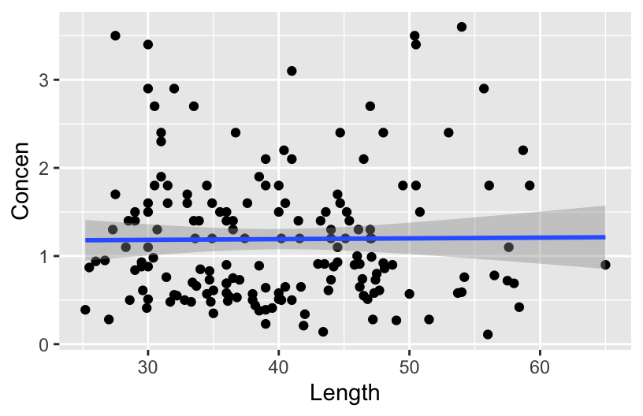

```r
# Shuffle the Length values
# Run this chunk a few times!!
# Then plot the resulting sample data and model
fish %>%
  select(Concen, Length) %>%
  mutate(Length = sample(Length, size = length(Length), replace = FALSE)) %>%
  ggplot(aes(x = Length, y = Concen)) +
  geom_point() +
  geom_smooth(method = "lm")
```

```r
set.seed(1)
shuffled_models <- mosaic::do(500)*(
  fish %>%
  select(Concen, Length) %>%
  sample_n(size = length(Length), replace = TRUE) %>%
  mutate(Length = sample(Length, size = length(Length), replace = FALSE)) %>%
  with(lm(Concen ~ Length))
)
head(shuffled_models)
##   Intercept     Length     sigma  r.squared        F numdf dendf .row .index
## 1 0.9165014 0.01136718 0.8865891 0.01204811 2.060961     1   169    1      1
## 2 0.9165014 0.01136718 0.8865891 0.01204811 2.060961     1   169    1      2
## 3 0.9165014 0.01136718 0.8865891 0.01204811 2.060961     1   169    1      3
## 4 0.9165014 0.01136718 0.8865891 0.01204811 2.060961     1   169    1      4
## 5 0.9165014 0.01136718 0.8865891 0.01204811 2.060961     1   169    1      5
## 6 0.9165014 0.01136718 0.8865891 0.01204811 2.060961     1   169    1      6
```

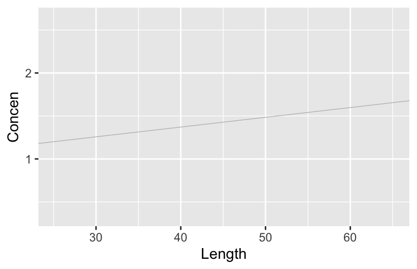

```r
# Plot the 500 shuffled models
fish %>%
  ggplot(aes(x = Length, y = Concen)) +
  geom_abline(data = shuffled_models,
              aes(intercept = Intercept, slope = Length),
              color = "gray", size = 0.25) +
  geom_smooth(method = "lm", se = FALSE, size = 0) # Ignore this line. It's a clunky workaround
```

4. Finally, focus on just the *slope* estimates $\hat{\beta}_1$ behind the lines above. Summarize your observations!! If there were truly no relationship between `Concen` and `Length`, i.e. $\beta_1$ were truly 0, how would we expect the sample slopes to behave?

```r
shuffled_models %>%
  ggplot(aes(x = Length)) +
  geom_density()
```

[output not shown]

## Exercise 2: Comparing our sample results to the null value (intuition)

Now that we’ve simulated how sample data might behave if there were truly no relationship between `Concen` and `Length` (i.e. if $\beta_1$ were 0), let’s consider the next important step in a **hypothesis test**:

Evaluate how compatible our observed sample data are with this assumption that $\beta_1 = 0$!

1. Let’s start with a visual assessment. Is *our* sample model (blue line) consistent / compatible with the “null models” simulated under the assumption the $\beta_1 = 0$ (gray lines)?

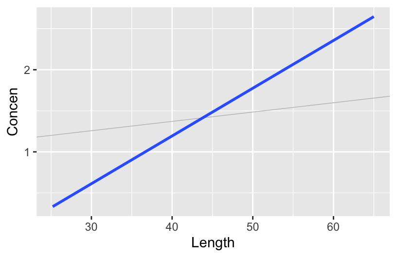

```r
fish %>%
  ggplot(aes(x = Length, y = Concen)) +
  geom_abline(data = shuffled_models,
              aes(intercept = Intercept, slope = Length),
              color = "gray", size = 0.25) +
  geom_smooth(method = "lm", se = FALSE)
```

2. Consider another visual assessment, focusing just on the *slopes* of the lines in the plot above, i.e. our sample estimates $\hat{\beta}_1$. Is *our* sample slope of $\hat{\beta}_1 = 0.05813$ (blue line) consistent / compatible with the collection of slopes from the “null models” (density plot)?

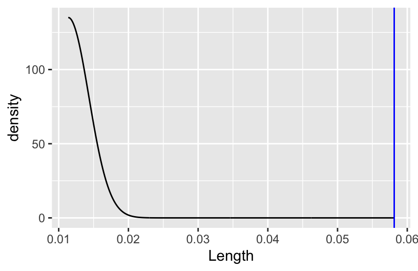

```r
shuffled_models %>%
  ggplot(aes(x = Length)) +
  geom_density() +
  geom_vline(xintercept = 0.05813, color = "blue")
```

3. In Part b, you evaluated the compatibility of *our* sample slope $\hat{\beta}_1 = 0.05813$ model with slopes of the “null models” using visual cues alone. But for a formal hypothesis test, we need some *numerical* measures of compatibility. Brainstorm some ideas!